# kNN classification for cancer

Feng, Chen

```r
library(dplyr)
library(knitr)
library(caret)
library(pROC)
```

# Loading Data

```r
set.seed(123)
df <- read.csv("wdbc.data", header = FALSE)

names <- c(
  'ID', 'Diagnosis', 'radius1', 'texture1', 'perimeter1', 'area1',
  'smoothness1', 'compactness1', 'concavity1', 'concave_points1',
  'symmetry1', 'fractal_dimension1', 'radius2', 'texture2', 'perimeter2',
  'area2', 'smoothness2', 'compactness2', 'concavity2', 'concave_points2',
  'symmetry2', 'fractal_dimension2', 'radius3', 'texture3', 'perimeter3',
  'area3', 'smoothness3', 'compactness3', 'concavity3', 'concave_points3',
  'symmetry3', 'fractal_dimension3'
)
colnames(df) <- names
```

#### In this step, I’m loading the dataset from my local folder. Since the file doesn’t have a header, I manually added column names.

# Basic Check

```r
head(df)
```

|  | ID | Diagnosis | radius1 | texture1 | perimeter1 | area1 | smoothness1 | compactness1 | concavity1 | concave_points1 | symmetry1 | fractal_dimension1 | radius2 | texture2 | perimeter2 | area2 | smoothness2 | compactness2 | concavity2 | concave_points2 | symmetry2 | fractal_dimension2 | radius3 | texture3 | perimeter3 | area3 | smoothness3 | compactness3 | concavity3 | … |
| --- | --- | --- | --- | --- | --- | --- | --- | --- | --- | --- | --- | --- | --- | --- | --- | --- | --- | --- | --- | --- | --- | --- | --- | --- | --- | --- | --- | --- | --- | --- |
| 1 | 842302 | M | 17.99 | 10.38 | 122.80 | 1001.0 | 0.11840 | 0.27760 | 0.3001 | 0.14710 | 0.2419 | 0.07871 | 1.0950 | 0.9053 | 8.589 | 153.40 | 0.006399 | 0.04904 | 0.05373 | 0.01587 | 0.03003 | 0.006193 | 25.38 | 17.33 | 184.60 | 2019.0 | 0.1622 | 0.6656 | 0.7119 | … |
| 2 | 842517 | M | 20.57 | 17.77 | 132.90 | 1326.0 | 0.08474 | 0.07864 | 0.0869 | 0.07017 | 0.1812 | 0.05667 | 0.5435 | 0.7339 | 3.398 | 74.08 | 0.005225 | 0.01308 | 0.01860 | 0.01340 | 0.01389 | 0.003532 | 24.99 | 23.41 | 158.80 | 1956.0 | 0.1238 | 0.1866 | 0.2416 | … |
| 3 | 84300903 | M | 19.69 | 21.25 | 130.00 | 1203.0 | 0.10960 | 0.15990 | 0.1974 | 0.12790 | 0.2069 | 0.05999 | 0.7456 | 0.7869 | 4.585 | 94.03 | 0.006150 | 0.04006 | 0.03832 | 0.02058 | 0.02250 | 0.004571 | 23.57 | 25.53 | 152.50 | 1709.0 | 0.1444 | 0.4245 | 0.4504 | … |
| 4 | 84348301 | M | 11.42 | 20.38 | 77.58 | 386.1 | 0.14250 | 0.28390 | 0.2414 | 0.10520 | 0.2597 | 0.09744 | 0.4956 | 1.1560 | 3.445 | 27.23 | 0.009110 | 0.07458 | 0.05661 | 0.01867 | 0.05963 | 0.009208 | 14.91 | 26.50 | 98.87 | 567.7 | 0.2098 | 0.8663 | 0.6869 | … |
| 5 | 84358402 | M | 20.29 | 14.34 | 135.10 | 1297.0 | 0.10030 | 0.13280 | 0.1980 | 0.10430 | 0.1809 | 0.05883 | 0.7572 | 0.7813 | 5.438 | 94.44 | 0.011490 | 0.02461 | 0.05688 | 0.01885 | 0.01756 | 0.005115 | 22.54 | 16.67 | 152.20 | 1575.0 | 0.1374 | 0.2050 | 0.4000 | … |
| 6 | 843786 | M | 12.45 | 15.70 | 82.57 | 477.1 | 0.12780 | 0.17000 | 0.1578 | 0.08089 | 0.2087 | 0.07613 | 0.3345 | 0.8902 | 2.217 | 27.19 | 0.007510 | 0.03345 | 0.03672 | 0.01137 | 0.02165 | 0.005082 | 15.47 | 23.75 | 103.40 | 741.6 | 0.1791 | 0.5249 | 0.5355 | … |

```r
missing<-data.frame(apply(df, 2, function(x) sum(is.na(x))))
colnames(missing) <- "Missing Number"
missing
```

|  | Missing Number |
| --- | --- |
| ID | 0 |
| Diagnosis | 0 |
| radius1 | 0 |
| texture1 | 0 |
| perimeter1 | 0 |
| area1 | 0 |
| smoothness1 | 0 |
| compactness1 | 0 |
| concavity1 | 0 |
| concave_points1 | 0 |

[output cut: 22 more lines]

```r
prop.table(table(df$Diagnosis))
```

```
##
##         B         M
## 0.6274165 0.3725835
```

```r
names(df)[!sapply(df, is.numeric)]
```

```
## [1] "Diagnosis"
```

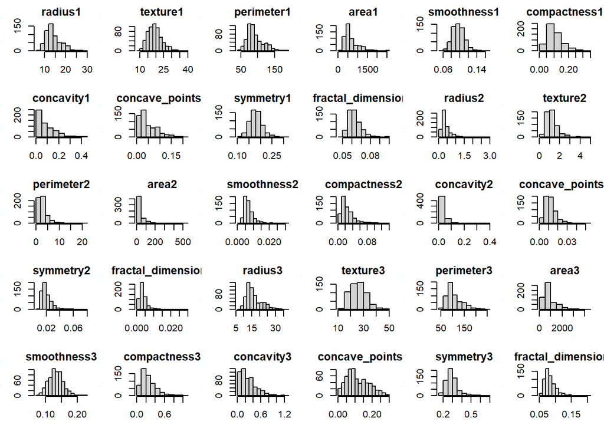

```r
par(mfrow = c(5, 6), mar = c(3,3,2,1))
invisible(mapply(function(x, nm) hist(x, main = nm, xlab = nm), df[3:32], names(df[3:32])))
```

#### Here, I’m doing some quick checks, missing values, data types, and class balance for the target column (Diagnosis), just to get an idea of the data quality. I also plotted histograms for all numeric columns (except ID and Diagnosis) to see the overall distribution of each feature.

# Convert Diagnosis into Factor

```r
df$Diagnosis <- factor(df$Diagnosis, levels = c("M", "B"))
```

#### I converted the target column Diagnosis into a two-level factor, with “M” first and “B” second. This helps later when calculating things like ROC or AUC.

# Check for Outliers

```r
normalized <- subset(df, select = -c(ID, Diagnosis))
t <- data.frame(Column=character(), Outliers=integer(), Percentage=numeric(),
                stringsAsFactors = FALSE)
for (i in colnames(normalized)) {
  m <- mean(df[[i]], na.rm = TRUE)
  s <- sd(df[[i]], na.rm = TRUE)
  z <- abs((df[[i]] - m) / s)
  rows.outliers <- which(z > 3)
  percent <- round((length(rows.outliers)/nrow(df))*100, 1)

  t <- rbind(t, data.frame(Column = i,
                           Outliers = length(rows.outliers),
                           Percentage = percent))
}

kable(t, caption = "Outliers", align = 'c')
```

Outliers

| Column | Outliers | Percentage |
| --- | --- | --- |
| radius1 | 5 | 0.9 |
| texture1 | 4 | 0.7 |
| perimeter1 | 7 | 1.2 |
| area1 | 8 | 1.4 |
| smoothness1 | 5 | 0.9 |
| compactness1 | 9 | 1.6 |
| concavity1 | 9 | 1.6 |
| concave_points1 | 6 | 1.1 |
| symmetry1 | 5 | 0.9 |
| fractal_dimension1 | 7 | 1.2 |
| radius2 | 7 | 1.2 |
| texture2 | 9 | 1.6 |
| perimeter2 | 8 | 1.4 |
| area2 | 6 | 1.1 |
| smoothness2 | 7 | 1.2 |
| compactness2 | 12 | 2.1 |
| concavity2 | 6 | 1.1 |
| concave_points2 | 6 | 1.1 |
| symmetry2 | 11 | 1.9 |
| fractal_dimension2 | 10 | 1.8 |
| radius3 | 6 | 1.1 |
| texture3 | 4 | 0.7 |
| perimeter3 | 6 | 1.1 |
| area3 | 10 | 1.8 |
| smoothness3 | 3 | 0.5 |
| compactness3 | 10 | 1.8 |
| concavity3 | 7 | 1.2 |
| concave_points3 | 0 | 0.0 |
| symmetry3 | 9 | 1.6 |
| fractal_dimension3 | 9 | 1.6 |

```r
normalized$Diagnosis <- df$Diagnosis
```

#### In this step, I checked for outliers using a z-score method with threshold of z > 3. This helps show how many extreme values each column has and the percentage of outliers overall. I didn’t remove them since they only make up a small portion of the data.

# Train-Test Split

```r
sample_size <- floor(0.8 * nrow(normalized))
set.seed(123)
index <- sample(seq_len(nrow(normalized)), size = sample_size)

train <- normalized[index, ]
test  <- normalized[-index, ]

train.x <- subset(train, select = -Diagnosis)
train.y <- train$Diagnosis
test.x  <- subset(test, select = -Diagnosis)
test.y  <- test$Diagnosis
```

#### I split the dataset into 80% training and 20% testing, which is a standard ratio for most machine learning tasks. The training set is used to train the model, and the test set is used at the end to evaluate its performance.

# Normalization with Z-score

```r
m <- sapply(train.x, mean)
s <- sapply(train.x, sd)
scale_with <- function(X, m, s) as.data.frame(sweep(sweep(X, 2, m, "-"), 2, s, "/"))
train.x_s<-scale_with(train.x, m, s)
test.x_s<-scale_with(test.x, m, s)
```

#### Here, I normalized all features using z-score scaling. The mean and standard deviation were calculated only from the training set to avoid data leakage, and then applied to both the training and test sets.

# Helper Functions

```r
knn_mode <- function(x) {
  ux <- unique(x)
  index <- match(x, ux)
  counts <- tabulate(index, length(ux))
  ux[which.max(counts)]
}

knn_distance <- function(p, q) {
  sqrt(sum((p - q)^2))
}

knn_all_dists <- function(train, u) {
  n <- nrow(train)
  v <- numeric(n)
  for (i in 1:n) {
    p <- train[i, ]
    v[i] <- knn_distance(p, u)
  }
  return(v)
}

knn_predict <- function(train_x, train_y, u, k) {
  if (is.data.frame(train_y)) train_y <- train_y[[1]]
  d <- knn_all_dists(as.matrix(train_x), as.numeric(u))
  ds <- order(d)[1:k]
  pred <- knn_mode(train_y[ds])
  factor(pred, levels = levels(train_y))
}

knn_predict_all <- function(train_x, train_y, test_x, k = 5) {
  n <- nrow(test_x)
  pred <- factor(rep(NA, n), levels = levels(train_y))
  for (i in 1:n) {
    u <- test_x[i, ]
    pred[i] <- knn_predict(train_x, train_y, u, k)
  }
  return(pred)
}


knn_score <- function(train_x, train_y, test_x, k) {
  if (is.data.frame(train_y)) train_y <- train_y[[1]]
  n <- nrow(test_x)
  scores <- numeric(n)
  pos = 'M'
  for (i in 1:n) {
    u <- test_x[i, ]
    d <- knn_all_dists(as.matrix(train_x), as.numeric(u))
    n <- order(d)[1:k]
    scores[i] <- mean(train_y[n] == pos)
  }
  scores
}

knn_acc <- function(test_y, pred, positive = 'M') {
  TP <- sum(test_y == positive & pred == positive)
  TN <- sum(test_y != positive & pred != positive)
  FP <- sum(test_y != positive & pred == positive)
  FN <- sum(test_y == positive & pred != positive)
  accuracy <- ((TP + TN) / length(pred)) * 100

  return(list(
    accuracy = accuracy,
    True_Positive = TP,
    True_Negative = TN,
    False_Positive = FP,
    False_Negative = FN
  ))
}
```

#### This section defines all the helper functions needed for k-NN:

- knn_mode: finds the most frequent label among neighbors.
- knn_distance: calculates Euclidean distance between two points.
- knn_all_dists: uses knn_distance to compute the distance between one sample and all points in the training data.
- knn_predict: uses those distances to predict one label.
- knn_predict_all: loops through all test samples to predict their labels.
- knn_score: calculates the fraction of “M” neighbors (used later for ROC/AUC).
- knn_acc: computes accuracy and returns confusion matrix metrics — TP, TN, FP, and FN.

# K Evaluation

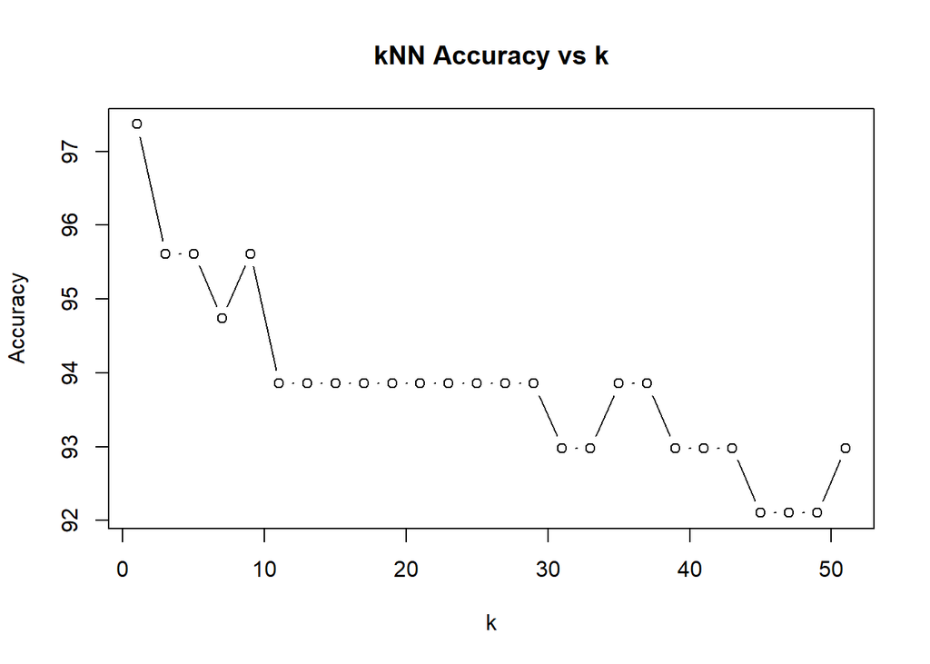

```r
k <- seq(1, 51, by = 2)
acc <- numeric(length(k))

for (i in seq_along(k)) {
  x <- k[i]
  prediction <- knn_predict_all(train_x = train.x_s, train_y = train.y, test_x = test.x_s, k = x)
  result <- knn_acc(test_y = test.y, pred = prediction)
  acc[i] <- result$accuracy
}

acc_k <- data.frame(k = k, accuracy = acc)
plot(acc_k$k, acc_k$accuracy, type = "b",
     xlab = "k", ylab = "Accuracy", main = "kNN Accuracy vs k")
```

```r
which.max(acc_k$accuracy)
```

```
## [1] 1
```

#### In this part, I tested different values of k from 1 to 51, to see how accuracy changes. The model performs best when k = 1, but to make sure, I’ll double-check it using cross-validation to confirm if it’s real or just overfitting.

# Cross Validation

```r
runs<-list()

for (i in 1:5) {
  folds <- createFolds(train.y, k = 10)
  cv_res <- data.frame(k=integer(), fold=integer(), Accuracy=double())
  for (f in seq_along(folds)) {
    idx <- folds[[f]]
    cv_train.x <- train.x[-idx, , drop=FALSE]
    cv_train.y <- train.y[-idx]
    cv_test.x <- train.x[idx, , drop=FALSE]
    cv_test.y <- factor(train.y[idx], levels = levels(train.y))
    m <- sapply(cv_train.x, mean)
    s <- sapply(cv_train.x, sd)
    cv_train.x <- scale_with(cv_train.x, m, s)
    cv_test.x <- scale_with(cv_test.x, m, s)
    for (K in k) {
      pred <- knn_predict_all(cv_train.x, cv_train.y, cv_test.x, K)
      acc  <- knn_acc(cv_test.y, pred)
      cv_res <- rbind(cv_res, data.frame(k = K, fold = f, Accuracy = acc$accuracy))
    }
  }
  summary <- aggregate(Accuracy ~ k, data = cv_res, mean)
  runs[[i]]<-summary
}

runs <- do.call(rbind, runs)
result <- runs %>%
  group_by(k) %>%
  summarise(
    Accuracy = mean(Accuracy, na.rm = TRUE),
    .groups = "drop"
  )
result
```

| k | Accuracy |
| --- | --- |
| 1 | 95.73904 |
| 3 | 96.56605 |
| 5 | 96.39021 |
| 7 | 95.81436 |
| 9 | 96.39122 |
| 11 | 96.52165 |
| 13 | 95.77383 |
| 15 | 95.51300 |
| 17 | 95.33619 |
| 19 | 95.46856 |

[output cut: 16 more lines]

```r
opt_k <-result$k[which.max(result$Accuracy)]
opt_k
```

```
## [1] 3
```

#### Here, I ran a 10-fold cross-validation, repeated 5 times, to find a more reliable value for k. Each fold uses a different subset of the training data for validation. Inside every fold, I re-scale the features based only on that fold’s training portion to keep things leak-free. After averaging all folds and runs, I picked the k with the highest mean accuracy as the final one.

# ROC & AUC

```r
score <- knn_score(train.x_s, train.y, test.x_s, k=opt_k)
roc <- roc(test.y, score)
roc
```

```
##
## Call:
## roc.default(response = test.y, predictor = score)
##
## Data: score in 53 controls (test.y M) > 61 cases (test.y B).
## Area under the curve: 0.979
```

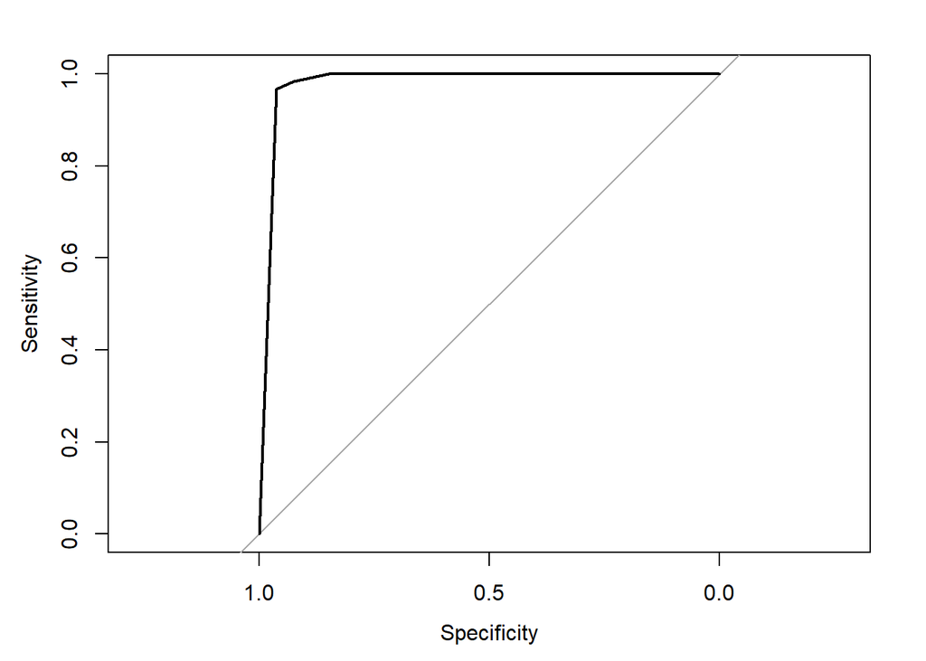

```r
plot(roc)
```

```r
auc(roc)
```

```
## Area under the curve: 0.979
```

#### Now that I have the optimal k, I calculated the ROC curve and AUC score using the test set. The score represents the probability of correctly distinguishing malignant (M) from benign (B) cases. AUC close to 1 means the model performs very well — in this case, 0.979, which is excellent.

# Final Prediction

```r
final_pred <- knn_predict_all(train.x_s, train.y, test.x_s, k=opt_k)
knn_acc(test.y, final_pred)
```

```
## $accuracy
## [1] 95.61404
##
## $True_Positive
## [1] 49
##
## $True_Negative
## [1] 60
##
## $False_Positive
## [1] 1
##
## $False_Negative
## [1] 4
```

#### Finally, I used the best k from cross-validation to make predictions on the test set. The accuracy came out above 95%, showing that the model can classify malignant and benign cases with high confidence.